# Oikos_Workshop

## PART 2

Alright, so you guys have made it through the first part of the data visualization workshop. Are you in **love** with this kind of stuff yet? Isn’t it so much fun?

If you aren’t passionate about making your statistical nightmares into dreamy plotscapes, then maybe you just need a little bit of a challenge.

Here we go for part two.

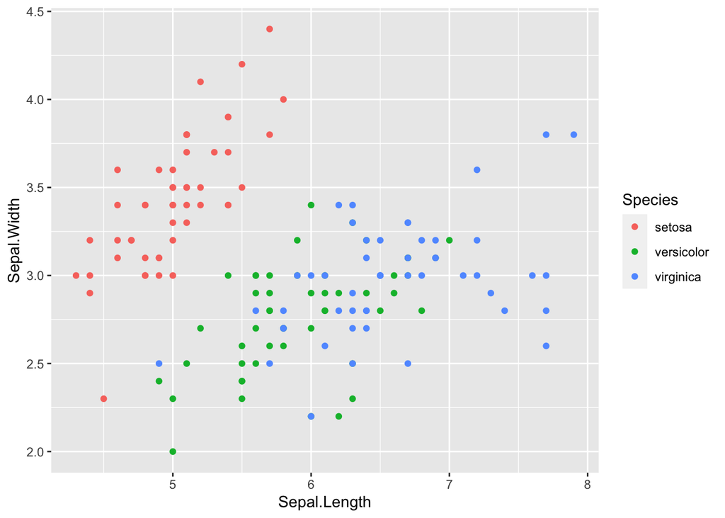

```r
#Let's call our iris data set (you've already loaded it, but here's a good excuse to remind yourself)
data("iris")

#Like with the wool data set, let's look at it a little bit to see what's going on.

ggplot(iris, aes( x = Sepal.Length, y = Sepal.Width, color = Species))+
  geom_point() # I like this one bests´data
```

```r
#Hmmm, definitely looks like these species have different lengths of sepals.
```

Coolio, we’ve foind something of potential interest here, let’s looking.

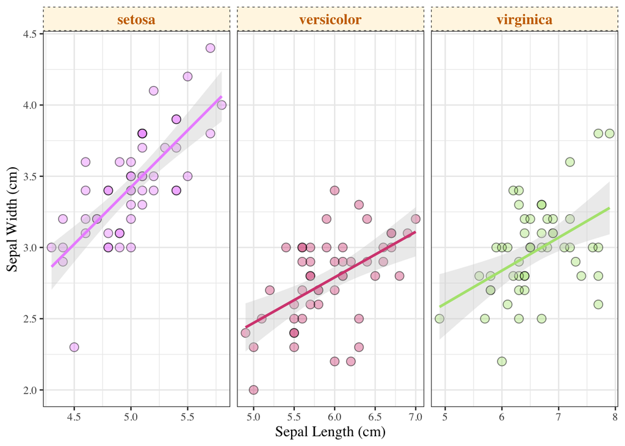

```r
ggplot(iris, aes( x = Sepal.Length, y = Sepal.Width, color = Species))+
  geom_point(size = 3, shape = 16, alpha = 0.4) +
  geom_point(size = 3, shape = 1, alpha = 0.5, color = "black")+ #did you know you can keep adding layers of points, of various sizes
  ylab("Sepal Width (cm)")+ #let's label some axes
  xlab("Sepal Length (cm)")+
  #look at what happens when I switch between color and fill

#Alright, now let's take this graph from a scatter plot to something challenging and functional!
#Let me introduce you to stat_smooth, which is a function that makes regression lines in your plot!
  stat_smooth(method = "glm", fill= "lightgrey", #lm, loess
              formula = y~ x, fullrange = F)+  #log(x), poly(x, 3); fullrange F/T
  facet_wrap(~ Species, scales = "free_x")+  #scales = "free_y" or "free"

#Alright, so often in ggplot, no one ever messes with the base theme, but it's completely customizable!
#The font, the background, the colors, everything! Now, let's try really messing everything up here. :=)

  theme_bw(base_family = "Times") + #change the text everywhere
  theme(
    legend.position = "none",
    axis.title =
      element_text(size = 12),
    strip.background = element_rect(fill = "#fff7e5", linetype = "dotted"),
    strip.text= element_text(
                             size = 12,
                             face = "bold",
                             color = "#ca6e00")) +
  scale_color_manual(values = c("#ec94ff", "#d64b80", "#b1e37e"))
```

```r
###############
#### BONUS ---- ##
################

#Using dplyr to make gramatically correct plots!

#You might be also wondering about how to change the species names to have captial letters!
#This information can be changed pretty easily,

#Make sure you have dplyr loaded for this

iris$Species<- recode(iris$Species,
                      setosa = "Setosa",
                      versicolor = "Versicolor",
                      virginica = "Virginica")


#After you run this, you can run the plot again.
#Usually, we would put all of the dplyr/tidyr modifications at the beginning of the script (that way you only run everything once),
#but it's here for teaching purposes.
```

## PART 3

Well, I hope you’ve learned something through all of this! The next plot it probably the highest probability of people getting lost, but hopefully the first two plots have taught you enough to either be able to come and revisit this later and figure the code out or to follow along the first try!

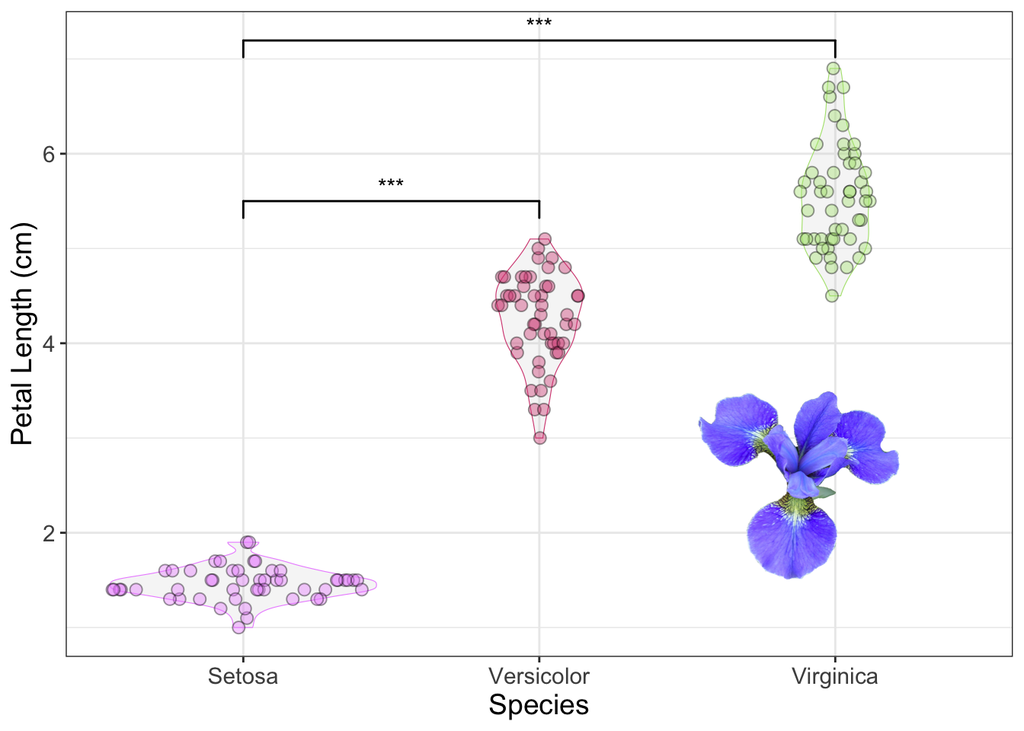

```r
#################################
#Adding pictures to your graph! ----
#Read the last chunk if you need help setting up your working directory and loading pictures
#################################
img <- readPNG("iris1.png") #save your image, the title is whatever you named it. Mine is called iris1
i1 <- grid::rasterGrob(img, interpolate = T)

#See, just two lines of code! Now, add this to your original ggplot in annotation_custom

#We've been looking at sepals, so what not look at some petals!
ggplot(iris, aes( x = Species, y = Petal.Length))+
  geom_violin(fill = "lightgrey", aes(color = Species),
              #NOTE: see I moved color here, try moving it around and see what happens!
              size = 0.2, alpha = 0.2) +
  #Let's play with some violin plots here, note that size in this case are line thickness
  #When we just look at the distributions, what can we already see?
  geom_sina(alpha = 0.4, size = 2.5,
            shape = 21,
            aes(fill = Species)) +
#Sina plots are a lot like jitter plots except that they are controlled by density!
#Which makes them a perfect pair to go with density plots.

#Alright, let's add some singificant comparisons!
#**NEVER DO THIS WITHOUT HAVING STATISTICAL CONFIMATION; BELOW IS FOR TEACHING PURPOSES ONLY**
#Run list with capital letters if you did the bonus in part 2. if you skipped it, make sure
#you keep them the way they are originally coded in the dataset.
  geom_signif(comparisons = list(c("Virginica", "Setosa")), map_signif_level = TRUE)+
  geom_signif(comparisons = list(c("Versicolor", "Setosa")), y_position = 5.5, map_signif_level = TRUE)+
  #sina functions where the width
  #of the jitter is controlled by the density distribution of the data
  theme_bw()+
  theme(legend.position = "none",
        text = element_text(size = 14))+
  ylab("Petal Length (cm)")+
  scale_fill_manual(values = c("#ec94ff", "#d64b80", "#b1e37e"))+
  scale_color_manual(values = c("#ec94ff", "#d64b80", "#b1e37e")) +

  #Alright let's take a coffee break before we go attacking adding images into plots.
  #Find a picture of an iris flower, and save it in your working directory. (see below)
  annotation_custom(i1, #this is my picture!
                    ymin = 1.5,
                    ymax = 3.5,
                    xmin =1.75,
                    xmax = 4)
```

Alright, so for adding pictures, you need to put the picture file (.png) in your working directory. First, let’s find out where that is on your computer! (Usually it’s your desktop if you haven’t done anything to it)

Here we see my working directory if a folder on my Desktop called Oikos (yay! Oikos 2021 woooooooo!). So, I would need to drag my image there.

Now, check your working directory. Where is it? If you have something really weird, just set it to your desktop for now. Once that’s taken care of, go to the previous chunk.

```r
getwd()
```

```
## [1] "/Users/chloefouilloux/Desktop/Oikos"
```

```r
#If I wanted to set my working directory to my destop, I would just copy and paste what I had from my getwd()
#until the /Desktop. Then, just paste that into your setwd() and you will be good to go!

#setwd()
```

**Questions?**

Read more about the significance package (ggsignif) here : https://cran.r-project.org/web/packages/ggsignif/vignettes/intro.html